# R Notebook

# ATP stim: 20231009_ATPstim_3dayPLX_longstim – FBS free media in the assay

First pass visualizing the results of the experiment (details can be found on elab). See `~/Melanoma/Ca2Mobilization/20231009_ATPstim_3dayPLX_longstim` directory for thunor .tsv platemap and for barcode information.

pERK staining procedure and imaging details can be found in the elab entry titled 20231009_ATPstim_pERK_3day_60min_PLX

## Data processing details

MetaExpress multiwavelength cell scoring analysis performed with the settings saved in: “VQU_PES_Ca2+ mobilization”

```r
library(diprate)
library(ggplot2)
library(viridis)
library(tidyr)
library(ggridges)
library(dplyr)
```

### Function to quantify ppERK using both proportion of positive cells and the avg intensity

Using both proportion of cells staining positively for ppERK and the integrated values of the positive cells.

```r
ppERKint <- function(dat, signif=4) {
    cell_count <- nrow(dat)
    pos_cells <- nrow(dat[dat$positive.w2==1,])
    val <- pos_cells/cell_count*sum(dat[dat$positive.w2==1,]$avg.pERK)
    val <- signif(val,signif)
    return(val)
}
```

## Load data

```r
fn <- "https://www.dropbox.com/scl/fi/29bpvy97lhxk30f72tumq/20231009_singlecell_all_ATP.csv?rlkey=hm03jle80pivcvw7hgncy00ml&dl=1"
d <- read.csv(fn)
```

# QC

### Filtering (QC)

```r
o_nrow <- nrow(d)
d <- d[d$total.area < 4500 & d$total.area > 50 & d$w2.stain.integr.intens <5e6,]
message(cat("Current nrow = ",nrow(d),"\nOriginal nrow = ",o_nrow))
```

```
Current nrow =  622161
Original nrow =  644947
```

```r
message(cat("QC removed",signif(100-(nrow(d)/o_nrow*100),2),"% of cells"))
```

```
QC removed 3.5 % of cells
```

```r
plot(d$w2.stain.integr.intens, d$total.area, pch=20,
     col=c("red","orange","yellow")[match(d$BRAFi.tx.time, unique(d$BRAFi.tx.time))])
legend("topleft",legend=unique(d$BRAFi.tx.time),fill=c("red","orange","yellow"))
```

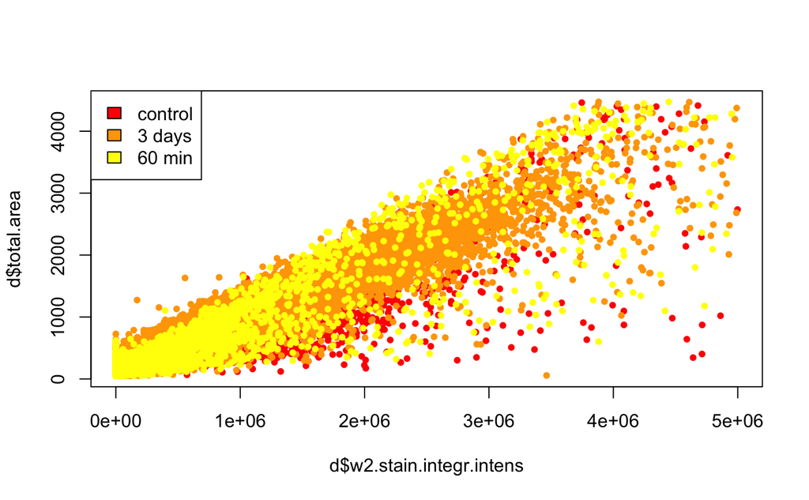

```r
text(4e7,0,paste("# cells =",nrow(d)))
```

### `drug2.conc` missing in data

Had to remove from `keepcols`

```r
keepcols <- c("cell.line","drug1","drug1.conc","drug2","well",
              "BRAFi.tx.time","atp.tx.time",
              "cell.id","total.area","positive.w2","w2.stain.area","w2.stain.integr.intens", "avg.pERK")

d <- d[,keepcols]
```

```r
ab_ctrl_wells <- unique(d[d$drug1=="" & d$drug2=="",]$well)
untx_ctrl_wells <- unique(d[d$drug2=="control",]$well)
ctrl_wells <- c(ab_ctrl_wells,untx_ctrl_wells)

d[is.na(d$drug1.conc),"drug1.conc"] <- 0
d[is.na(d$drug2.conc),"drug2.conc"] <- 0

d[d$drug1=="","drug1"] <- "control"

tx <- tibble(d[!d$well %in% ctrl_wells, ])
tx <- tx[order(tx$BRAFi.tx.time),]

rownames(tx) <- NULL

ctrls <- d[d$well %in% ctrl_wells, ]

tx$drug1.conc <- signif(tx$drug1.conc, digits= 2)
tx$drug1 <- factor(tx$drug1)
```

### Controls

- `drug1 == "holiday"`: BRAFi-treated cells given a “holiday”; replaced medium with FBS-free, undrugged media
- `drug1 == "persistent"`: BRAFi maintained, no agonist added
- `drug1 == "control"`: Drug-naive cells in FBS free medium (no PLX or ionomycin ever added)
- `drug1 == "controlFBS"`: Drug-naive cells in FBS-containing medium
- `drug1 == "" & drug2 == ""`: Antibody controls (1° and 2°)

```r
ctrlType <- function(drug1)
    switch(drug1,
           controlFBS="naive_wFBS",
           control="naive_woFBS",
           drug1
           )


d$ctrl_type <- sapply(d$drug1, function(x)
    ifelse(x %in% c("","control","controlFBS","holiday","persistent"),ctrlType(x),""))

d[d$drug1=="" & is.na(d$drug2),"ctrl_type"] <- "ab_ctrl"
d[d$ctrl_type=="","ctrl_type"] <- NA
d$ctrl_type <- factor(d$ctrl_type)
unique(d$ctrl_type)
```

```
[1] naive_woFBS naive_wFBS  <NA>        persistent
Levels: naive_wFBS naive_woFBS persistent
```

```r
dtp <- d[!is.na(d$ctrl_type),]
```

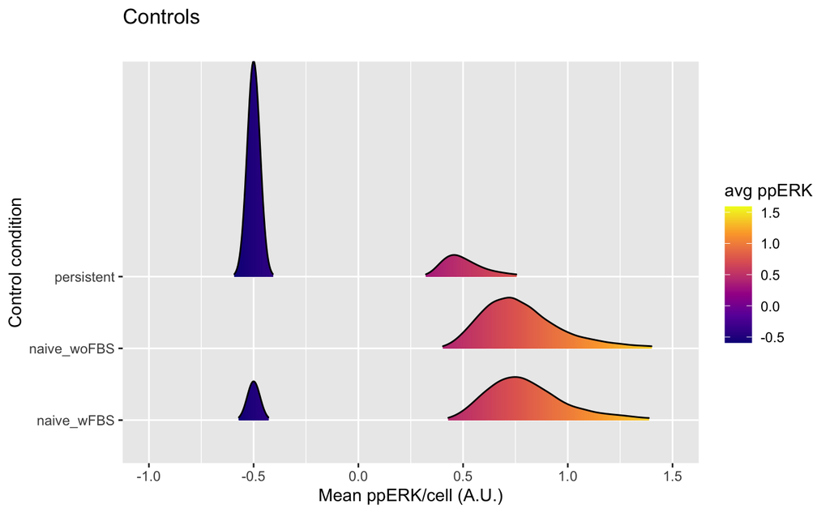

```r
ggplot(dtp, aes(x = avg.pERK, y = ctrl_type, fill = after_stat(x))) +
    xlim(-1,1.5) +
    geom_density_ridges_gradient(scale = 3, rel_min_height = 0.01) +
    scale_fill_viridis_c(name = "avg ppERK", option = "C") +
    labs(title = 'Controls',
         subtitle="") +
    xlab("Mean ppERK/cell (A.U.)") + ylab("Control condition")
```

```r
tx <- d[is.na(d$ctrl_type),]
drugs <- unique(tx$drug1)
```

```r
ppdf <-tx %>%
    group_by(BRAFi.tx.time, drug1, drug1.conc, atp.tx.time, positive.w2) %>%
    summarise(num= n())
ppdf$positive.w2 <- rep(c("negative","positive"), nrow(ppdf)/2)

pct.pos <- ppdf %>%
    spread(positive.w2, num) %>%
    mutate(total= negative+positive) %>%
    summarise(propos= positive/total) %>%
    ungroup()
```

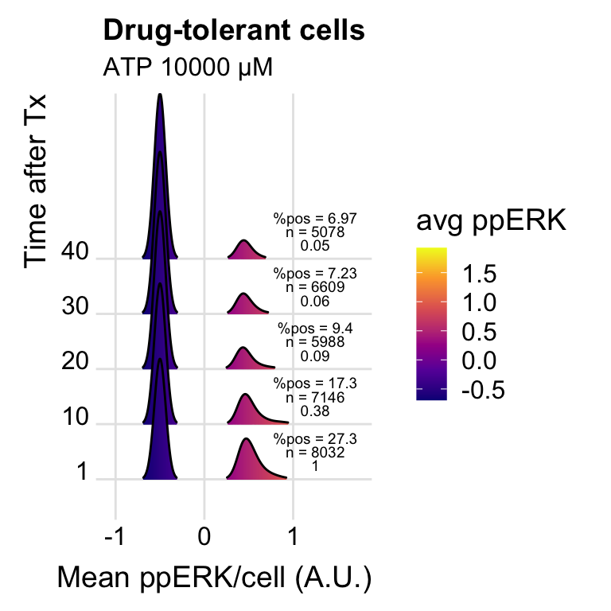

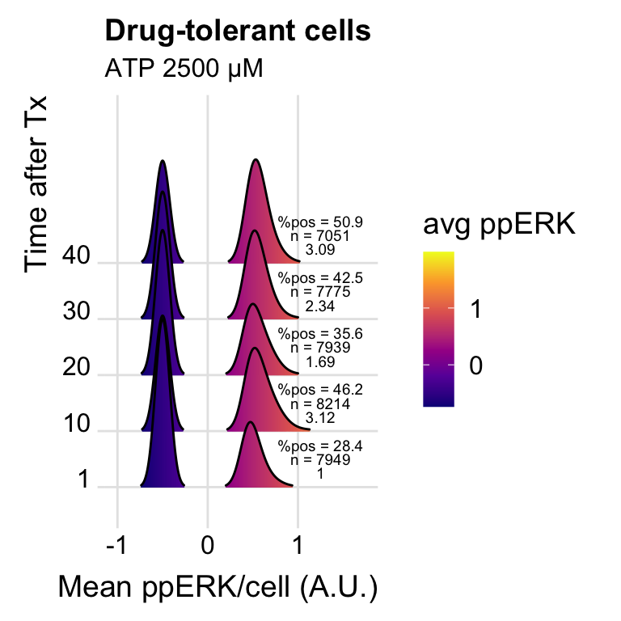

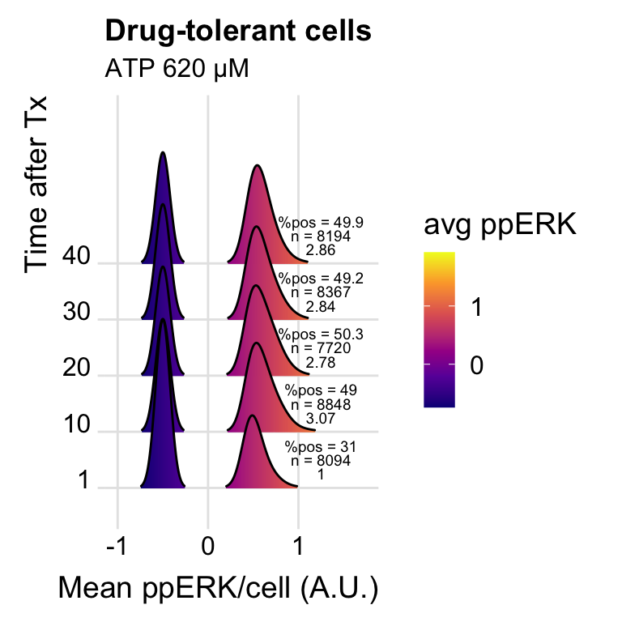

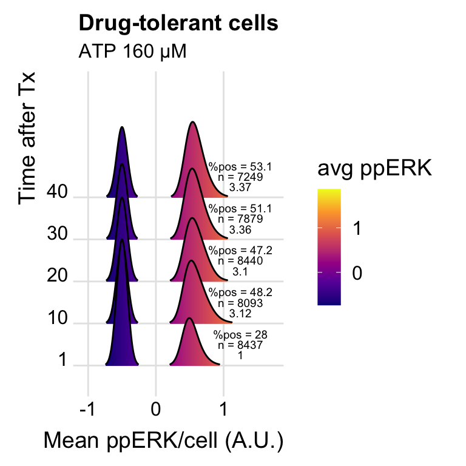

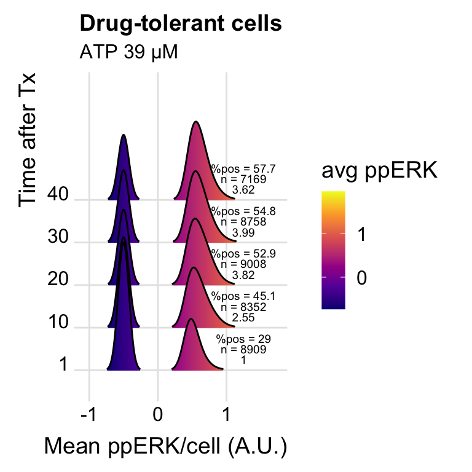

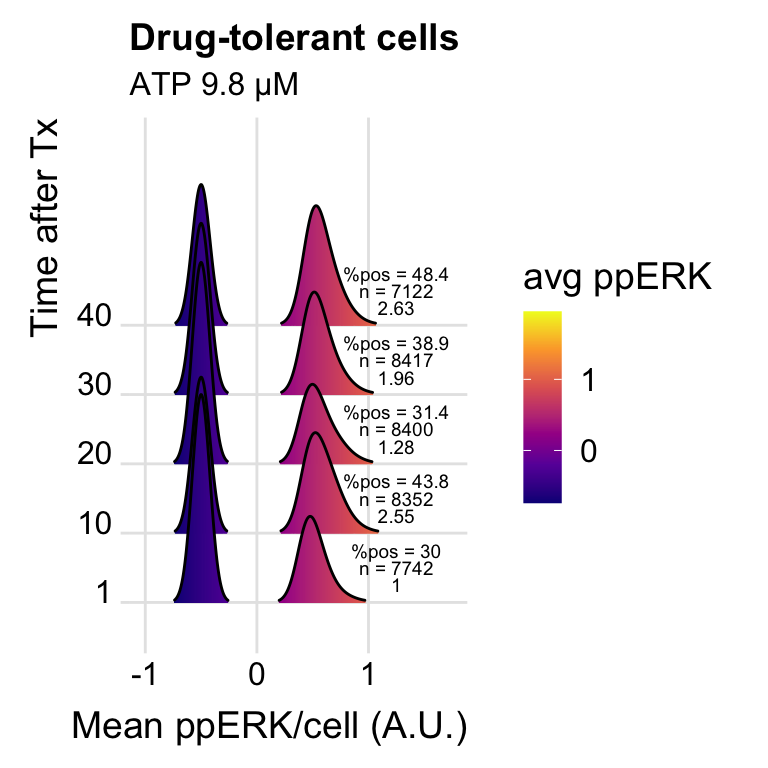

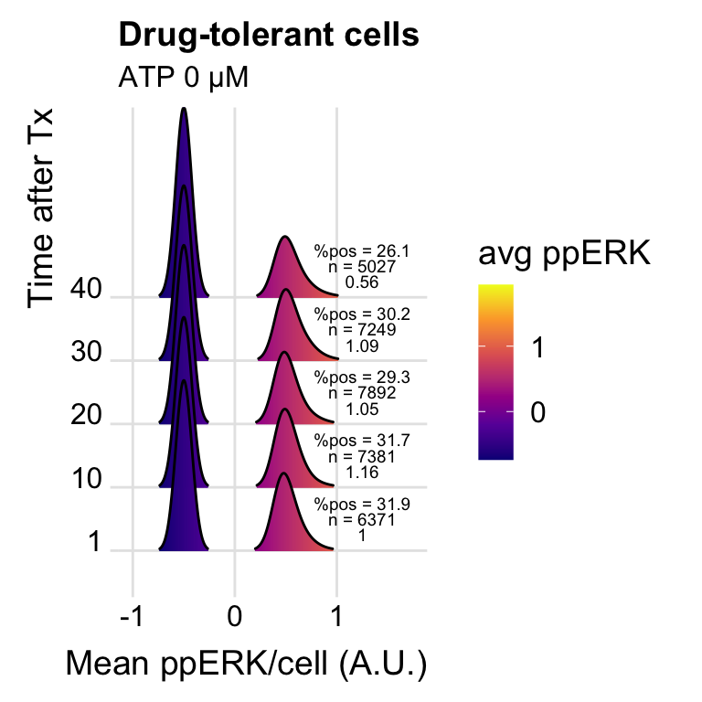

```r
dat <- tx[tx$drug1=="ATP" & tx$BRAFi.tx.time=="3 days",]


g <- lapply(unique(dat$drug1.conc), function(dc) {
    dtp <- dat[dat$drug1.conc==dc,]
    dtp <- dtp[order(dtp$atp.tx.time),]

    n_vals <- pct.pos[pct.pos$drug1.conc==dc & pct.pos$BRAFi.tx.time =="3 days",]
    n_vals$propos <- signif(n_vals$propos*100, 3)

    ppERK_vals <- sapply(unique(dtp$atp.tx.time), function(tt) ppERKint(dtp[dtp$atp.tx.time==tt,]))
    names(ppERK_vals) <- unique(dtp$atp.tx.time)
    ppERK_vals <- round(ppERK_vals/ppERK_vals[names(ppERK_vals)=="1"],2)

    out <- ggplot(dtp, aes(x = avg.pERK, y = factor(atp.tx.time), fill = after_stat(x))) +
        xlim(-1,1.75) +
        geom_density_ridges_gradient(scale = 3, rel_min_height = 0.01) +
        scale_fill_viridis_c(name = "avg ppERK", option = "C") +
        labs(title = 'Drug-tolerant cells',
             subtitle=paste(unique(dtp$drug1),signif(dc*1e6, 2), "µM")) +
        xlab("Mean ppERK/cell (A.U.)") + ylab("Time after Tx") +
        annotate("text", x=1.25, y=1:(length(ppERK_vals))+0.25, label=ppERK_vals, size=2.5) +


        annotate("text", x=1.25, y=1.75, label=
                     paste("%pos =",n_vals[n_vals$atp.tx.time==1,"propos"]), size=2.5) +

        annotate("text", x=1.25, y=2.75, label=
                     paste("%pos =",n_vals[n_vals$atp.tx.time==10,"propos"]), size=2.5) +

        annotate("text", x=1.25, y=3.75, label=
                     paste("%pos =",n_vals[n_vals$atp.tx.time==20,"propos"]), size=2.5) +

        annotate("text", x=1.25, y=4.75, label=
                     paste("%pos =",n_vals[n_vals$atp.tx.time==30,"propos"]), size=2.5) +

        annotate("text", x=1.25, y=5.75, label=
                     paste("%pos =",n_vals[n_vals$atp.tx.time==40,"propos"]), size=2.5) +
        annotate("text", x=1.25, y=1.5, label= paste("n =",nrow(dtp[dtp$atp.tx.time==1,])), size=2.5) +
        annotate("text", x=1.25, y=2.5, label= paste("n =",nrow(dtp[dtp$atp.tx.time==10,])), size=2.5) +
        annotate("text", x=1.25, y=3.5, label= paste("n =",nrow(dtp[dtp$atp.tx.time==20,])), size=2.5) +
        annotate("text", x=1.25, y=4.5, label= paste("n =",nrow(dtp[dtp$atp.tx.time==30,])), size=2.5) +
        annotate("text", x=1.25, y=5.5, label= paste("n =",nrow(dtp[dtp$atp.tx.time==40,])), size=2.5)

    out <- out + theme_ridges()
    if(dc != 0) out <- out + scale_y_discrete(expand = expand_scale(mult = c(0.15, .75)))
    out
})

g
```

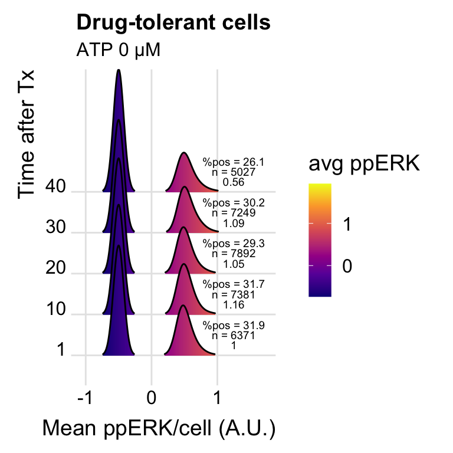

```r
g[[7]]
```

```r
# ggsave("~/Desktop/0uM_ATP-induced_ppERK_drug-tol.pdf", height=4, width=4, units="in", device="pdf")
```

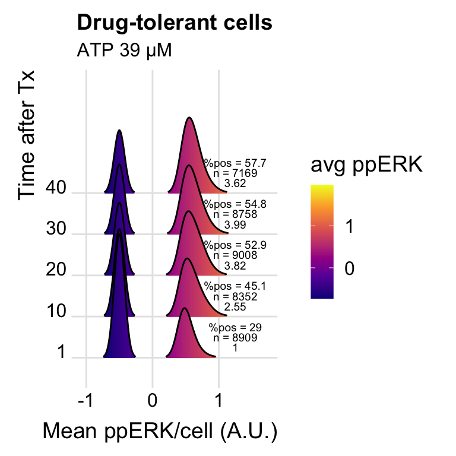

```r
g[[5]]
```

```r
# ggsave("~/Desktop/39uM_ATP-induced_ppERK_drug-tol.pdf", height=4, width=4, units="in", device="pdf")
```

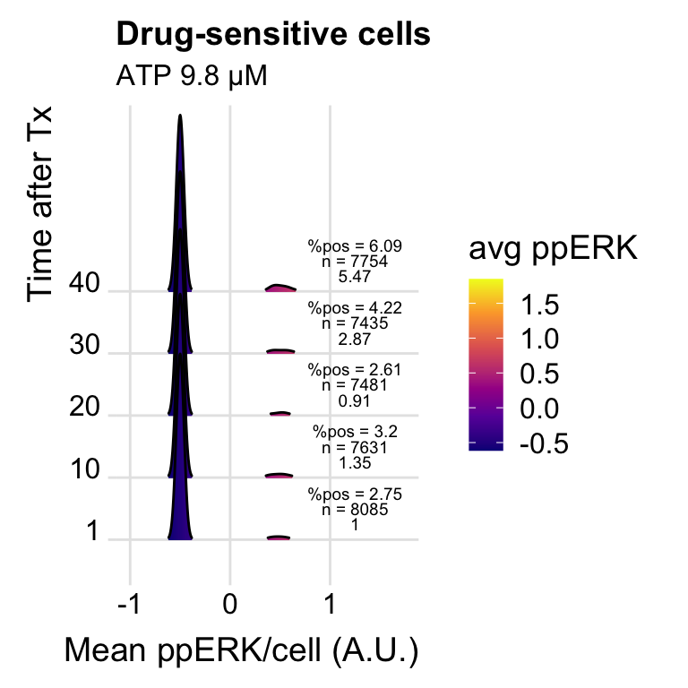

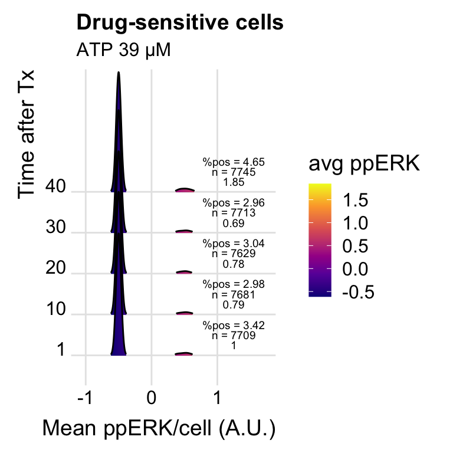

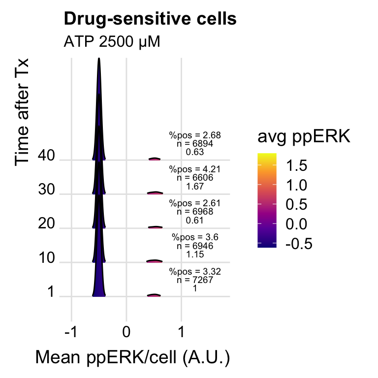

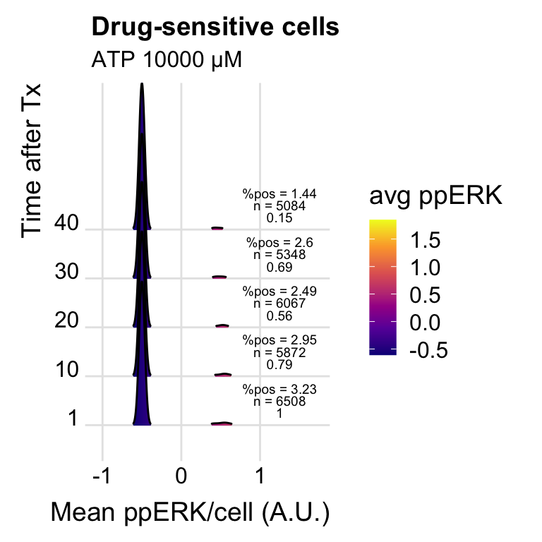

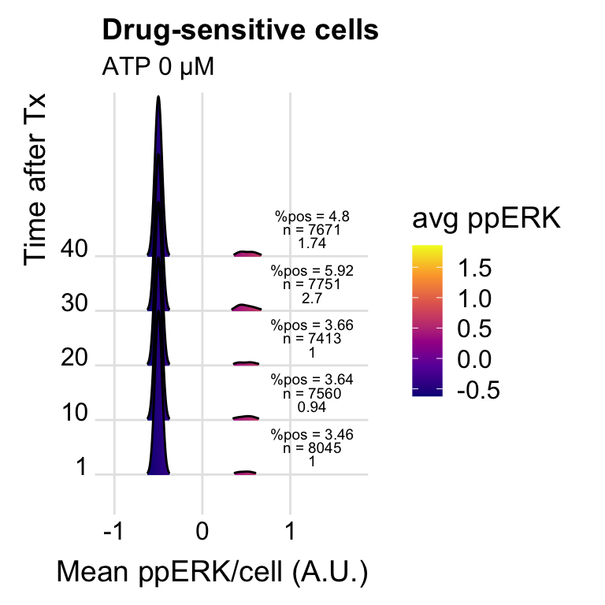

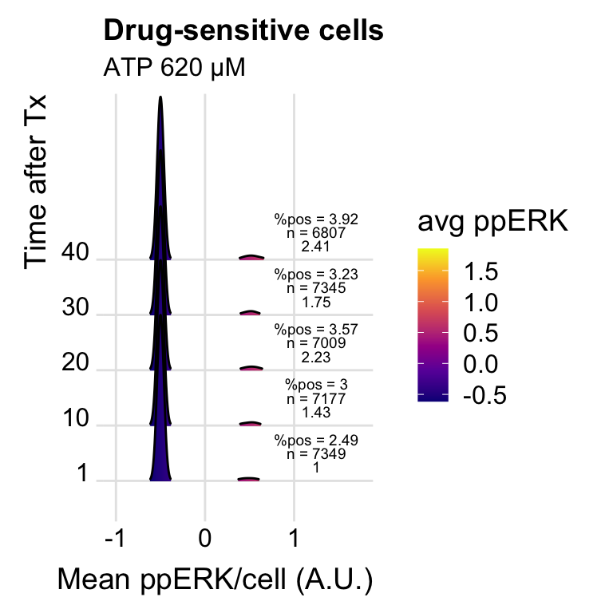

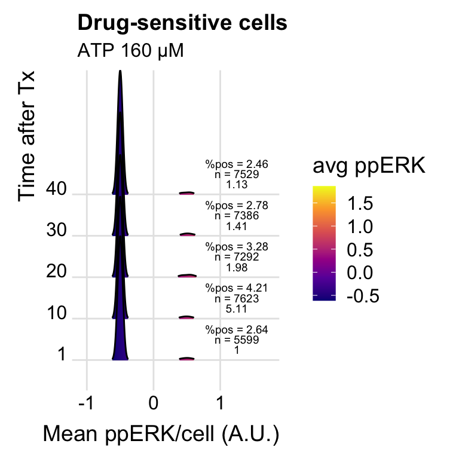

```r
dat <- tx[tx$drug1=="ATP" & tx$BRAFi.tx.time=="60 min",]

g <- lapply(unique(dat$drug1.conc), function(dc) {
    dtp <- dat[dat$drug1.conc==dc,]
    dtp <- dtp[order(dtp$atp.tx.time),]

    n_vals <- pct.pos[pct.pos$drug1.conc==dc & pct.pos$BRAFi.tx.time =="60 min",]
    n_vals$propos <- signif(n_vals$propos*100, 3)

    ppERK_vals <- sapply(unique(dtp$atp.tx.time), function(tt) ppERKint(dtp[dtp$atp.tx.time==tt,]))
    names(ppERK_vals) <- unique(dtp$atp.tx.time)
    ppERK_vals <- round(ppERK_vals/ppERK_vals[names(ppERK_vals)=="1"],2)

    out <- ggplot(dtp, aes(x = avg.pERK, y = factor(atp.tx.time), fill = after_stat(x))) +
        xlim(-1,1.75) +
        geom_density_ridges_gradient(scale = 3, rel_min_height = 0.01) +
        scale_fill_viridis_c(name = "avg ppERK", option = "C") +
        labs(title = 'Drug-sensitive cells',
             subtitle=paste(unique(dtp$drug1),signif(dc*1e6, 2), "µM")) +
        xlab("Mean ppERK/cell (A.U.)") + ylab("Time after Tx") +
        annotate("text", x=1.25, y=1:(length(ppERK_vals))+0.25, label=ppERK_vals, size=2.5) +


        annotate("text", x=1.25, y=1.75, label=
                     paste("%pos =",n_vals[n_vals$atp.tx.time==1,"propos"]), size=2.5) +

        annotate("text", x=1.25, y=2.75, label=
                     paste("%pos =",n_vals[n_vals$atp.tx.time==10,"propos"]), size=2.5) +

        annotate("text", x=1.25, y=3.75, label=
                     paste("%pos =",n_vals[n_vals$atp.tx.time==20,"propos"]), size=2.5) +

        annotate("text", x=1.25, y=4.75, label=
                     paste("%pos =",n_vals[n_vals$atp.tx.time==30,"propos"]), size=2.5) +

        annotate("text", x=1.25, y=5.75, label=
                     paste("%pos =",n_vals[n_vals$atp.tx.time==40,"propos"]), size=2.5) +
        annotate("text", x=1.25, y=1.5, label= paste("n =",nrow(dtp[dtp$atp.tx.time==1,])), size=2.5) +
        annotate("text", x=1.25, y=2.5, label= paste("n =",nrow(dtp[dtp$atp.tx.time==10,])), size=2.5) +
        annotate("text", x=1.25, y=3.5, label= paste("n =",nrow(dtp[dtp$atp.tx.time==20,])), size=2.5) +
        annotate("text", x=1.25, y=4.5, label= paste("n =",nrow(dtp[dtp$atp.tx.time==30,])), size=2.5) +
        annotate("text", x=1.25, y=5.5, label= paste("n =",nrow(dtp[dtp$atp.tx.time==40,])), size=2.5)

    out <- out + theme_ridges()
    out <- out + scale_y_discrete(expand = expand_scale(mult = c(0.15, .75)))
    out
})

g
```

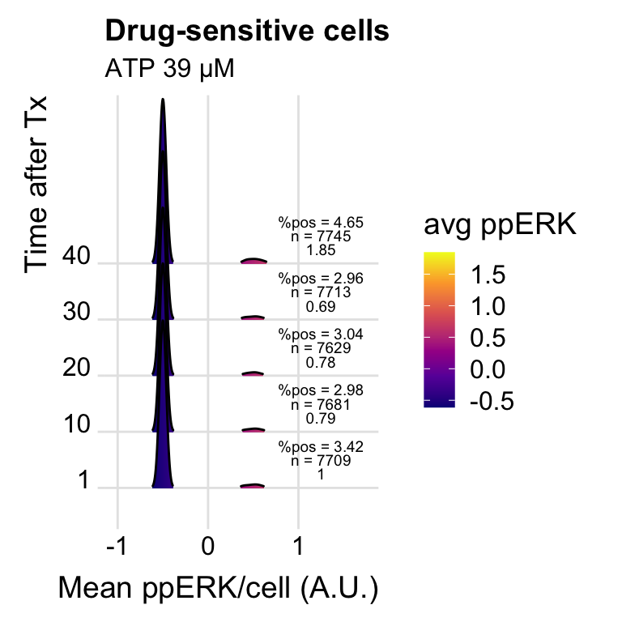

```r
g[[2]]
```

```r
# ggsave("~/Desktop/39uM_ATP-induced_ppERK_drug-sens.pdf", height=4, width=4, units="in", device="pdf")
```

[figure not shown]

```r
dat <- tx[tx$drug1=="ATP" & tx$atp.tx.time==20 & tx$BRAFi.tx.time=="3 days",]

ppERK_vals <- sapply(unique(dat$drug1.conc), function(dc) ppERKint(dat[dat$drug1.conc==dc,]))
names(ppERK_vals) <- unique(signif(dat$drug1.conc*10e6,2))
ppERK_vals <- round(ppERK_vals/ppERK_vals[names(ppERK_vals)=="0"],2)
ppERK_vals <- rev(ppERK_vals[order(as.integer(names(ppERK_vals)))])

ggplot(dat, aes(x = avg.pERK, y = factor(signif(drug1.conc*10e6,2)), fill = after_stat(x))) +
    xlim(-1,1.5) +
    geom_density_ridges_gradient(scale = 3, rel_min_height = 0.01) +
    scale_fill_viridis_c(name = "avg ppERK", option = "C") +
    labs(title = 'Drug-tolerant cells',
         subtitle="20 min Tx") +
    xlab("Mean ppERK/cell (A.U.)") + ylab("[ATP], µM") +
    annotate("text", x=1.25, y=(7:1)+0.5, label=ppERK_vals, size=2.5)
```

```r
# ggsave("~/Desktop/ATP_dose-dependent_ppERK_drug-tol.pdf", width=4, height=4, units="in", device="pdf")
```

[figure not shown]

```r
dat <- tx[tx$drug1=="ATP" & tx$atp.tx.time==20 & tx$BRAFi.tx.time=="60 min",]

ppERK_vals <- sapply(unique(dat$drug1.conc), function(dc) ppERKint(dat[dat$drug1.conc==dc,]))
names(ppERK_vals) <- unique(signif(dat$drug1.conc*10e6,2))
ppERK_vals <- round(ppERK_vals/ppERK_vals[names(ppERK_vals)=="0"],2)
ppERK_vals <- rev(ppERK_vals[order(as.integer(names(ppERK_vals)))])

ggplot(dat, aes(x = avg.pERK, y = factor(signif(drug1.conc*10e6,2)), fill = after_stat(x))) +
    xlim(-1,1.5) +
    geom_density_ridges_gradient(scale = 3, rel_min_height = 0.01) +
    scale_fill_viridis_c(name = "avg ppERK", option = "C") +
    labs(title = 'Drug-sensitive cells',
         subtitle="20 min Tx") +
    xlab("Mean ppERK/cell (A.U.)") + ylab("[ATP], µM") +
    annotate("text", x=1.25, y=(7:1)+0.5, label=ppERK_vals, size=2.5)
```

```r
# ggsave("~/Desktop/ATP_dose-dependent_ppERK_drug-sens.pdf", width=4, height=4, units="in", device="pdf")
```